# Project Proposal

Dion, Julie, Mia, Vincent

## Data

The dataset we have chosen to explore is **“The Complete Pokemon Dataset”** on Kaggle. It is under the Creative Commons Public Domain license, so we are completely free to use the data in any way we’d like. https://www.kaggle.com/rounakbanik/pokemon

## Research Questions

There are 3 main questions we would like to cover in this project.

1. What is the correlation between height and weight of a Pokemon with its base stats?

Rationale: It is often speculated that a bigger and taller Pokemon generally translates into better base stats. How true is that? Or maybe height and weight does not make a difference at all? We are eager to find out.

2. Is it possible to build a classifier to identify legendary Pokemon? Which classification method, logistic regression or decision tree, is the more suitable and accurate one?

Rationale: An essential element of playing Pokemon is to encounter and collect legendary Pokemon. However, as one gets older and more isolated from the latest trend in Pokemon, it is not immediately obvious if a certain Pokemon is legendary or not. Thus, it would be helpful to have a classifier to tell us that based on the traits exhibited in a variety of predictors.

3. If you were to win in a Pokemon league, what would be your chosen six?

Rationale: For avid Pokemon players, nothing is more exciting than building the ultimate team. We will look into a variety of importants variables here when building our model, such as type, type_against, hp, attack, defense, sp_attack, sp_defense, speed and so on.

## Exploratory Data Analysis

```r
pokemon <- read.csv("pokemon.csv")
```

Our data frame is massive with 801 observations of 41 variables. Therefore we will first remove unnecessary data.

```r
pokemon_trimmed <- subset(pokemon, select = -c(1, 21, 22, 24, 27, 30, 31, 32))
pokemon_trimmed <- pokemon_trimmed[,c(25,1:24,26:33)]
```

We will remove the following data: abilities, base egg steps, base happiness, capture rate, experience growth, japanese name, name, and percentage male. We will index each pokemon with their pokedex number and move that column to the leftmost position.

```r
unique(unlist(pokemon[,2:19]))
```

```
## [1] 1.00 0.50 0.25 2.00 4.00 0.00
```

Columns 2 to 19 (against [type]) and column 32 (generation) have quantitative categorical data. We will term the row sum across columns 2 to 19 “Total Resistance” and visualise the data using a histogram.

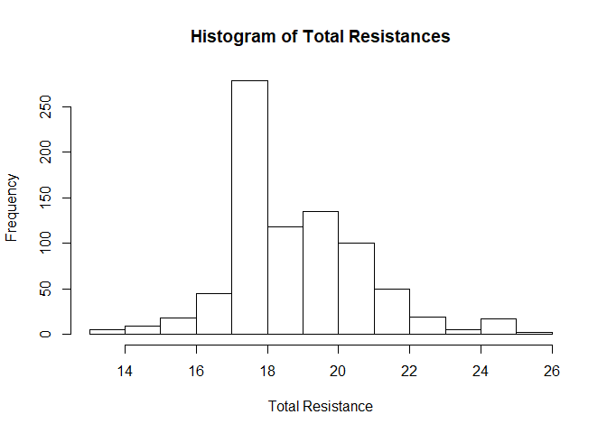

```r
hist(rowSums(pokemon_trimmed[,2:19]), main = "Histogram of Total Resistances", xlab = "Total Resistance")
```

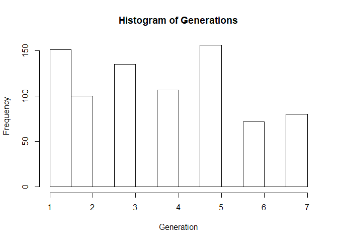

```r
hist(pokemon_trimmed[,32], main = "Histogram of Generations", xlab = "Generation")
```

Our total resistance data is approximately normally distributed except for a large number of pokemon with a total resistance of between 17 and 18, which makes the distribution slightly right-skewed. Our generation data is approximately uniformly distributed except for a smaller than average number of generation 6 and 7 pokemon.

Columns 22 (classification), 29 (type1), and 30 (type2) have qualitative categorical data. Column 33 (is_legendary) has binary data. We will use the “summary” function on these.

```r
summary(pokemon_trimmed[,c(22,29,30)])
```

```
##            classfication     type1         type2
##  Dragon PokÃ©mon  :  8   water  :114          :384
##  Mouse PokÃ©mon   :  6   normal :105   flying : 95
##  Mushroom PokÃ©mon:  6   grass  : 78   ground : 34
##  Balloon PokÃ©mon :  5   bug    : 72   poison : 34
##  Fairy PokÃ©mon   :  5   psychic: 53   fairy  : 29
##  Flame PokÃ©mon   :  5   fire   : 52   psychic: 29
##  (Other)          :766   (Other):327   (Other):196
```

```r
summary(pokemon_trimmed[,33]==1)
```

```
##    Mode   FALSE    TRUE
## logical     731      70
```

All other columns have continuous quantitative data. We will visualise these with a scatterplot matrix (except for the index: pokedex number).

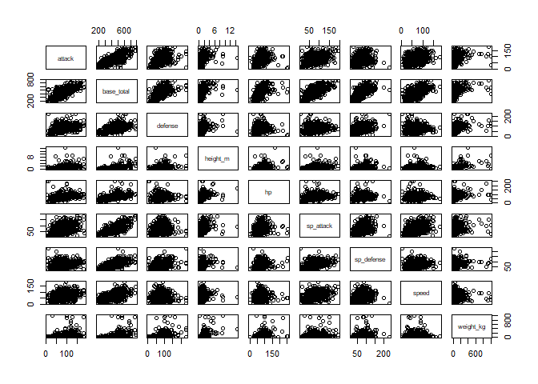

```r
cont_pokemon <- subset(pokemon_trimmed, select = -c(1,2:19,22,29,30,32,33))
pairs(cont_pokemon)
```

## Timeline of Group Project

As a group, we have decided to meet every Thursday, 6pm-7pm to discuss progress on the group project with a specific agenda outlined in the timeline.

### 1. Week 10 (17th-24th October):

What are the main classifications we can use to answer our possible research questions?:

**Vincent, Mia**: Look at the possibility of decision trees, and discuss issues with overfitting. **Julie, Dion**: Look into the possibility of k-means clustering, taking into account standardization of attributes.

### 2. Week 11 (25th-31st October):

Having decided the main classification techniques, and possibly exploring other methods, we will work on ensuring the model has useful predictors that we can use for our final group presentation in November.

**Julie, Mia**: Look up Kaggle datasets that approximate our chosen model, and compare the existing work made by teammates. **Vincent, Dion**: Depending on availability, consult with Prof Willem on the code for the process and seek some feedback.

### 3. Week 12 (1st-8 Nov):

As this is before a lot of final mid-terms for all group mates (who have shared their dates with each other), the focus will be to finish the bulk of the presentation and the diagnostics for the presentation. We will also have ad hoc rehearsals in the remaining time.

**Vincent, Mia**: Will structure and organize the aesthetics for the presentation. **Julie, Dion**: Will evaluate, improve and finalize the code for the presentation.

## Teamwork

We predict an equal share of the work taken on by all team members, adjusted to their relative time constraints and their capacities.

*Vincent*: As an MCS major, Vincent Will help out in the creation of classification techniques in Weeks 10-11.

*Mia*: Will be involved in the preprocessing of the dataset, diagnostics on the effectiveness of the classification after the code is written by other team members, and the background research on the effectiveness of these techniques using Kaggle course resources

*Julie*: As an MCS Major, Julie will help with the classification techniques and creating slides.

*Dion*: Also as an MCS Major, Dion will contribute to the EDA and improving the clarity and efficiency of the code.